# Group 1 - Final R Code

Hsiao Wei Liu

2023-08-08

The project explores Sephora skincare product reviews in the United States, focusing on two research questions. First, we identify the most frequently mentioned attributes in customer reviews through sentiment analysis and text mining. Second, we investigate customer preferences among different skin-tone subgroups. By categorizing reviews based on sentiments and attributes for each subgroup, we are able to gain insights into customer perceptions and preferences. This analysis empowers Sephora to make data-driven decisions to tailor marketing strategies to specific customer segments.

## Load Data

```r
review_raw = read.csv('/Users/vivian/Desktop/Columbia 24/5205 AA Framework 2/AAFWII Group Project/1st Submission - Project Proposal/reviews_0_250.csv')
```

## Select Columns Needed for Analysis

```r
colnames(review_raw)
```

```
##  [1] "X"                        "author_id"
##  [3] "rating"                   "is_recommended"
##  [5] "helpfulness"              "total_feedback_count"
##  [7] "total_neg_feedback_count" "total_pos_feedback_count"
##  [9] "submission_time"          "review_text"
## [11] "review_title"             "skin_tone"
## [13] "eye_color"                "skin_type"
## [15] "hair_color"               "product_id"
## [17] "product_name"             "brand_name"
## [19] "price_usd"
```

```r
library(dplyr)
review_clean = review_raw %>%
  select(author_id, review_text, skin_tone)

head(review_clean)
```

|  | author_id | review_text | skin_tone |
| --- | --- | --- | --- |
| 1 | 1741593524 | I use this with the Nudestix “Citrus Clean Balm & Make-Up Melt“ to double cleanse and it has completely changed my skin (for the better). The make-up melt is oil based and removes all of your makeup s… |  |
| 2 | 31423088263 | I bought this lip mask after reading the reviews and the hype. Unfortunately, it did not meet my expectations as vaseline petroleum jelly works way better for me. |  |
| 3 | 5061282401 | My review title says it all! I get so excited to get into bed and apply this lip mask. I do see a difference because I suffer from dry cracked lips. I drink a lot of water and apply lip balm daily but… | light |
| 4 | 6083038851 | I’ve always loved this formula for a long time. I honestly don’t even use it for night time. I use it as an everyday lip balm. I love the texture. Gummy Bear is my second most favourite scent. Grapefr… |  |
| 5 | 47056667835 | If you have dry cracked lips, this is a must have. After a few weeks of use I have learned I will always have by my bedside. I thought it was a little expensive but a little goes a long way. It is wor… | light |
| 6 | 42802569154 | The scent isn’t my favourite but it works great! I put it on every night before I go to sleep and every morning I wake up with smooth, moisturizer and soft. Packaging is amazing as well | lightMedium |

## Explore Data

### Data Structure

```r
str(review_clean)
```

```
## 'data.frame':    602130 obs. of  3 variables:
##  $ author_id  : chr  "1741593524" "31423088263" "5061282401" "6083038851" ...
##  $ review_text: chr  "I use this with the Nudestix “Citrus Clean Balm & Make-Up Melt“ to double cleanse and it has completely changed"| __truncated__ "I bought this lip mask after reading the reviews and the hype. Unfortunately, it did not meet my expectations a"| __truncated__ "My review title s…
##  $ skin_tone  : chr  "" "" "light" "" ...
```

### Skin Tone of Reviewers

Since “” and “notSureST” should be excluded from the skin tone categories, the dataset includes 13 different skin tones.

```r
unique(review_raw$skin_tone)
```

```
##  [1] ""            "light"       "lightMedium" "fairLight"   "fair"
##  [6] "medium"      "notSureST"   "mediumTan"   "tan"         "rich"
## [11] "olive"       "deep"        "porcelain"   "dark"        "ebony"
```

```r
length(unique(review_clean$skin_tone))
```

```
## [1] 15
```

Let’s explore the count of each skin tone. As the bar chart shown, the top 3 common skin tones among Sephora’s customers would be “light”, “fair”, and “lightMedium”.

```r
library(ggplot2)
table(review_clean$skin_tone)
```

```
##
##                    dark        deep       ebony        fair   fairLight
##      106056         322       10864           1      112076       30612
##       light lightMedium      medium   mediumTan   notSureST       olive
##      141402      106251       37221       34428          41        1131
##   porcelain        rich         tan
##        1040        2896       17789
```

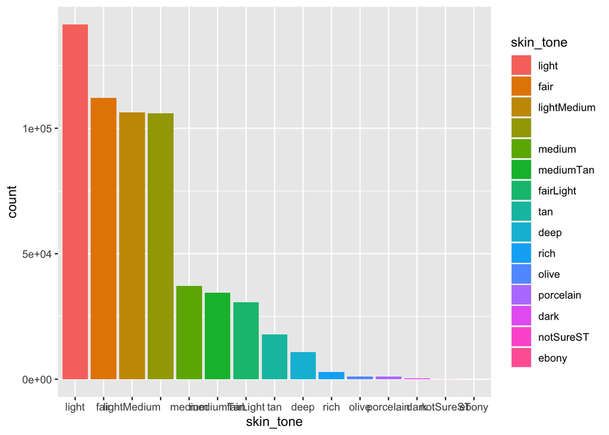

```r
skin_tone_df = as.data.frame(table(review_clean$skin_tone))
colnames(skin_tone_df) = c("skin_tone", "count")

skin_tone_df$skin_tone = factor(skin_tone_df$skin_tone,
                                levels = skin_tone_df$skin_tone[order(-skin_tone_df$count)])

ggplot(skin_tone_df, aes(x = skin_tone, y = count, fill = skin_tone)) +
  geom_bar(stat = "identity")
```

### Missing Values

Now let’s examine if there’s any missing value in our review data set.

```r
colSums(is.na(review_clean))
```

```
##   author_id review_text   skin_tone
##           0           0           0
```

Although it seems that there’s no missing value in the review_clean data. From our previous data exploration, we can see there’s `review_text` and `skin_tone` that contains empty content. So let’s double check how many empty rows of data is not captured by the is.na() function.

Turns out that 999 reviews and 106056 skin-tone data are empty. We transform these empty data points into NA values, so we can clean up these missing values easier in the following steps.

```r
sum(review_clean$review_text == "")
```

```
## [1] 999
```

```r
sum(review_clean$skin_tone == "")
```

```
## [1] 106056
```

```r
review_clean[(review_clean[,"review_text"] == ""), "review_text"] = NA
review_clean[(review_clean[,"skin_tone"] == ""), "skin_tone"] = NA

colSums(is.na(review_clean))
```

```
##   author_id review_text   skin_tone
##           0         999      106056
```

## Clean Data

### Transform skin_tone into Categories

Since there are too many types of skin tones, we decide to group the 13 types of skin tones into 3 main categories: light (light, fair, fairLight, porelain), medium (lightMedium, medium, mediumTan, olive), and tan (tan, deep, rich, dark, ebony) for our further analysis.

```r
library(dplyr)

# Create a mapping of each skin tone to 3 main categories
skin_tone_mapping = list(
  light = c("light", "fair", "fairLight", "porcelain"),
  medium = c("lightMedium", "medium", "mediumTan", "olive"),
  tan = c("tan", "deep", "rich", "dark", "ebony")
)

# Create a function to map each skin tones to 3 main categories
map_skin_tone = function(skin_tone) {
  main_category = NA
  for (category in names(skin_tone_mapping)) {
    if (skin_tone %in% skin_tone_mapping[[category]]) {
      main_category <- category
      break
    }
  }
  return(main_category)
}

# Apply the mapping to create a new column with main categories
review_clean = review_clean %>%
  mutate(skin_tone_cat = sapply(skin_tone, map_skin_tone)) %>%
  select(author_id, review_text, skin_tone_cat)

head(review_clean)
```

|  | author_id | review_text | skin_tone_cat |
| --- | --- | --- | --- |
| 1 | 1741593524 | I use this with the Nudestix “Citrus Clean Balm & Make-Up Melt“ to double cleanse and it has completely changed my skin (for the better). The make-up melt is oil based and removes all of your makeup s… | NA |
| 2 | 31423088263 | I bought this lip mask after reading the reviews and the hype. Unfortunately, it did not meet my expectations as vaseline petroleum jelly works way better for me. | NA |
| 3 | 5061282401 | My review title says it all! I get so excited to get into bed and apply this lip mask. I do see a difference because I suffer from dry cracked lips. I drink a lot of water and apply lip balm daily but… | light |
| 4 | 6083038851 | I’ve always loved this formula for a long time. I honestly don’t even use it for night time. I use it as an everyday lip balm. I love the texture. Gummy Bear is my second most favourite scent. Grapefr… | NA |
| 5 | 47056667835 | If you have dry cracked lips, this is a must have. After a few weeks of use I have learned I will always have by my bedside. I thought it was a little expensive but a little goes a long way. It is wor… | light |
| 6 | 42802569154 | The scent isn’t my favourite but it works great! I put it on every night before I go to sleep and every morning I wake up with smooth, moisturizer and soft. Packaging is amazing as well | medium |

### Drop Missing Values

Since the count of NA values are less than 20% of total number of data. We decide to drop all missing values by using the na.omit() function.

```r
review_clean = na.omit(review_clean)
colSums(is.na(review_clean))
```

```
##     author_id   review_text skin_tone_cat
##             0             0             0
```

```r
nrow(review_clean)
```

```
## [1] 495059
```

```r
# write.csv(review_clean, "review_clean.csv", row.names = FALSE)
```

## Text Mining and Sentiment Analysis

### For Research Question 1

#### Conduct Text Mining on All review_text

```r
# Tokenize review_text
library(dplyr); library(tidytext)
review_word_count = review_clean %>%
  select(author_id, review_text)%>%
  group_by(author_id)%>%
  unnest_tokens(output = word, input = review_text)%>%
  ungroup()%>%
  group_by(author_id)%>%
  summarize(count = n())

review_word_count
```

| author_id | count |
| --- | --- |
| 10000015049 | 10 |
| 10000060335 | 52 |
| 10000117144 | 309 |
| 10000120301 | 15 |
| 10000217994 | 169 |
| 10000247828 | 36 |
| 10000254625 | 52 |
| 10000290716 | 124 |
| 10000427309 | 16 |
| 10000569316 | 35 |

[output cut: 9990 more lines]

#### Conduct Sentiment Analysis on All review_text

```r
# Categorize Words in review_text Using Bing
sentiment_count = review_clean %>%
  group_by(author_id) %>%
  unnest_tokens(output = word, input = review_text) %>%
  inner_join(get_sentiments('bing')) %>%
  group_by(sentiment) %>%
  count()
sentiment_count
```

| sentiment | n |
| --- | --- |
| negative | 687469 |
| positive | 2128701 |

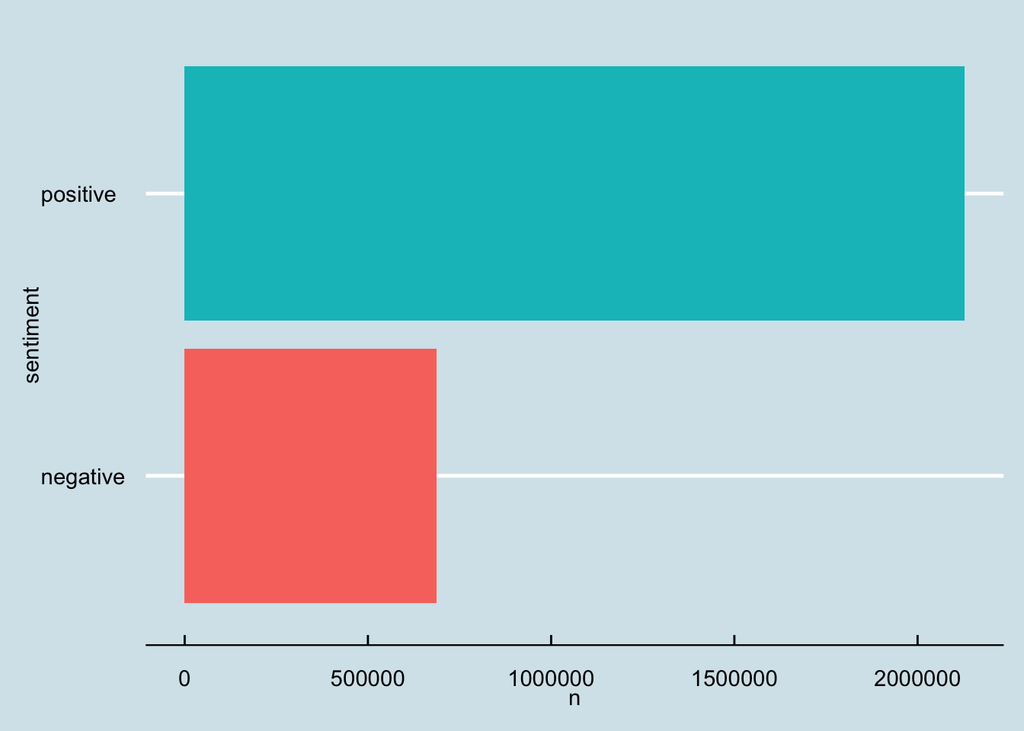

```r
library(ggthemes)
sentiment_count %>%
  ggplot(aes(x = sentiment, y = n, fill = sentiment)) +
  geom_col() +
  theme_economist() +
  guides(fill=F) +
  coord_flip()
```

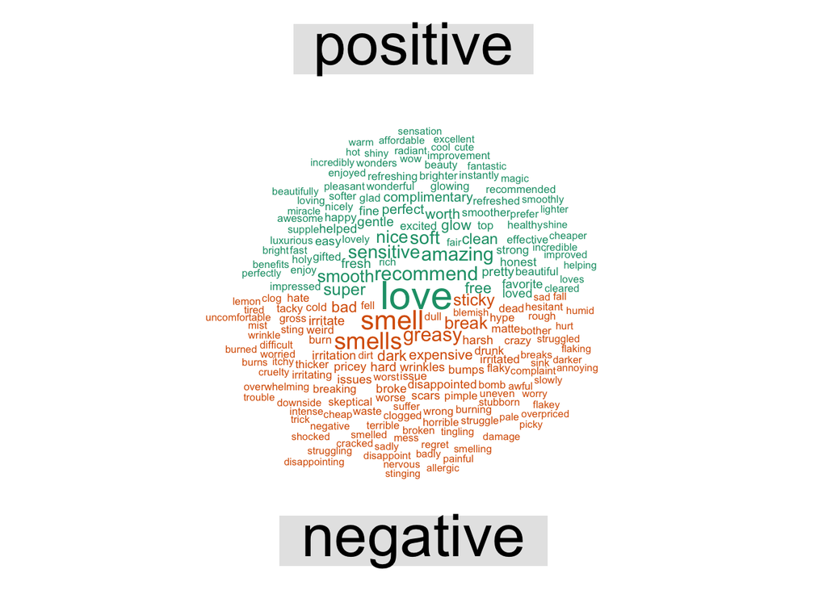

```r
# Visualize review_text Using Word Cloud

# install.packages('wordcloud')
library(wordcloud); library(tidyr)
wordcloudData =
  review_clean %>%
  group_by(author_id) %>%
  unnest_tokens(output = word, input = review_text) %>%
  ungroup() %>%
  select(author_id, word) %>%
  anti_join(stop_words) %>%
  inner_join(get_sentiments('bing')) %>%
  ungroup()%>%
  count(sentiment, word, sort = T) %>%
  pivot_wider(names_from = sentiment, values_from = n, values_fill = 0) %>%
  data.frame()
rownames(wordcloudData) = wordcloudData[,'word']
wordcloudData = wordcloudData[,c('positive','negative')]
set.seed(617)
comparison.cloud(term.matrix = wordcloudData,scale = c(2,0.5),max.words = 200, rot.per=0)
```

#### Measure Which Attribute Category Is Most Frequently Mentioned

```r
# Extract the words and frequencies from wordcloudData
words = rownames(wordcloudData)
positive_freq = wordcloudData$positive
negative_freq = wordcloudData$negative

# Combine the data into a data frame
word_freq_df = data.frame(word = words, positive = positive_freq, negative = negative_freq)

# View the top 20 rows of the positive reviews
pos_word = word_freq_df %>%
  select(word, positive) %>%
  arrange(desc(positive)) %>%
  slice(1:20)
pos_word
```

| word | positive |
| --- | --- |
| love | 189589 |
| recommend | 62888 |
| amazing | 60321 |
| sensitive | 56110 |
| soft | 55743 |
| nice | 49926 |
| smooth | 48968 |
| super | 44921 |
| free | 35030 |
| clean | 34518 |

[output cut: 10 more lines]

```r
# View the top 20 rows of the negative reviews
neg_word = word_freq_df %>%
  select(word, negative) %>%
  arrange(desc(negative)) %>%
  slice(1:20)
neg_word
```

| word | negative |
| --- | --- |
| smell | 49190 |
| smells | 40273 |
| greasy | 28221 |
| break | 21525 |
| sticky | 19649 |
| bad | 15829 |
| dark | 15051 |
| expensive | 12475 |
| irritate | 9159 |
| hard | 8882 |

[output cut: 10 more lines]

Based on our literature review, we know that the 4 main attributes that customers care the most when purchasing products are “price”, “quality” (including product smell, texture, functionality, and etc.), “package design”, and “ingredient”.

We group the most frequently mentioned words in both positive and negative reviews into these 4 categories. If the word doesn’t fit into any category, it would be put into the “others” categories.

```r
# Create a mapping of words to categories
word_category_mapping = data.frame(
  word = c("smell", "smells", "greasy", "break", "sticky",
           "bad", "dark", "expensive", "irritate", "hard",
           "wrinkles", "irritation", "harsh", "pricey", "issues",
           "broke", "disappointed", "scars", "bumps", "irritated",
           "love", "recommend", "amazing", "sensitive", "soft",
           "nice", "smooth", "super", "free", "clean",
           "glow", "worth", "perfect", "complimentary", "fresh",
           "gentle", "pretty", "helped", "loved", "fine"),
  category = c("quality", "quality", "quality", "quality", "quality",
               "quality", "others", "price", "others", "others",
               "quality", "others", "quality", "quality", "others",
               "others", "others", "quality", "quality", "others",
               "others", "others", "others", "quality", "quality",
               "others", "quality", "others", "price", "quality",
               "quality", "price", "others", "price", "quality",
               "quality", "package_design", "quality", "others", "others")
  )

# Merge the data frames to add the 'category' column to the original data (for positive reviews)
pos_word_freq = pos_word %>%
  left_join(word_category_mapping, by = "word") %>%
  group_by(category) %>%
  summarize(pos_review_count = sum(positive)) %>%
  arrange(desc(pos_review_count))

pos_word_freq
```

| category | pos_review_count |
| --- | --- |
| others | 467849 |
| quality | 289335 |
| price | 88885 |
| package_design | 20211 |

```r
# Merge the data frames to add the 'category' column to the original data (for negative reviews)
neg_word_freq = neg_word %>%
  left_join(word_category_mapping, by = "word") %>%
    group_by(category) %>%
    summarize(neg_review_count = sum(negative)) %>%
    arrange(desc(neg_review_count))

neg_word_freq
```

| category | neg_review_count |
| --- | --- |
| quality | 208602 |
| others | 66777 |
| price | 12475 |

#### Result

Let’s use chi-square test to measure if the counts in “quality” category is significantly different from others.

The null hypothesis (H0) for the chi-square test is that there is no significant difference in the counts of “quality” and other categories. The alternative hypothesis (Ha) is that there is a significant difference.

As the chi-square test results shown blow, both p-values are less than 0.05, indicating the word counts in “quality” category are significantly different from other categories, regardless of positive or negative reviews.

```r
library(stats)

# for "quality" category in the positive reviews
chisq.test(pos_word_freq$pos_review_count)
```

```
##
##  Chi-squared test for given probabilities
##
## data:  pos_word_freq$pos_review_count
## X-squared = 569313, df = 3, p-value < 2.2e-16
```

```r
# for "quality" category in the negative reviews
chisq.test(neg_word_freq$neg_review_count)
```

```
##
##  Chi-squared test for given probabilities
##
## data:  neg_word_freq$neg_review_count
## X-squared = 213750, df = 2, p-value < 2.2e-16
```

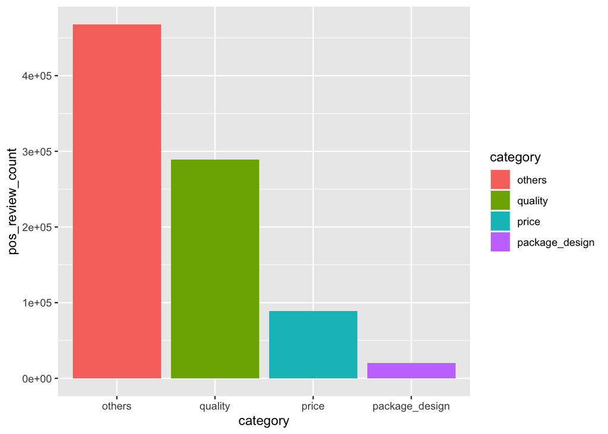

```r
# Visualize the Attribute Distribution (for positive reviews)
pos_word_freq$category = factor(pos_word_freq$category,
                                levels = pos_word_freq$category[order(-pos_word_freq$pos_review_count)])

ggplot(pos_word_freq, aes(x = category, y = pos_review_count, fill = category)) +
  geom_bar(stat = "identity")
```

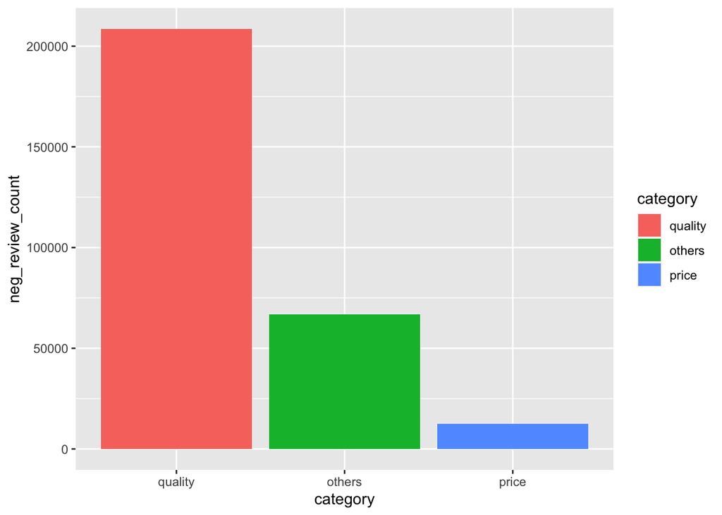

```r
# Visualize the Attribute Distribution (for negative reviews)
neg_word_freq$category = factor(neg_word_freq$category,
                                levels = neg_word_freq$category[order(-neg_word_freq$neg_review_count)])

ggplot(neg_word_freq, aes(x = category, y = neg_review_count, fill = category)) +
  geom_bar(stat = "identity")
```

### For Research Question 2

#### Conduct Sentiment Analysis on review_text from Light Skin-Tone Customers

```r
# Filter Out Reviews from Light Skin-Tone Customers
review_clean_light = review_clean %>%
  filter(skin_tone_cat == 'light')

head(review_clean_light)
```

|  | author_id | review_text | skin_tone_cat |
| --- | --- | --- | --- |
| 1 | 5061282401 | My review title says it all! I get so excited to get into bed and apply this lip mask. I do see a difference because I suffer from dry cracked lips. I drink a lot of water and apply lip balm daily but… | light |
| 2 | 47056667835 | If you have dry cracked lips, this is a must have. After a few weeks of use I have learned I will always have by my bedside. I thought it was a little expensive but a little goes a long way. It is wor… | light |
| 3 | 6941883808 | I’ll give this 2 stars for nice packaging and lovely scent. Upon initial application, it feels very nice. But as I continued to use it I noticed I was getting more and more blackheads/clogged pores an… | light |
| 4 | 27926227988 | I use this at night or while I’m putting makeup on. Love the way I don’t have to reapply it during the night. Definitely a win. | light |
| 5 | 7656791726 | I love this stuff. I first had the sample size from a Sephora Birthday gift, and once I had run through it I knew it was a purchase. I live in an incredibly dry environment, great for macarons, but te… | light |
| 6 | 38727834382 | I purchased the Sweet Candy scent at my local Sephora and I am OBSESSED!! I will be honest, the scent is a bit strong - but they’re all strongly scented. My lips are so soft. 10/10! | light |

```r
nrow(review_clean_light)
```

```
## [1] 284635
```

```r
# Categorize Words in review_text Using Bing
sentiment_count_light = review_clean_light %>%
  group_by(author_id) %>%
  unnest_tokens(output = word, input = review_text) %>%
  inner_join(get_sentiments('bing')) %>%
  group_by(sentiment) %>%
  count()
sentiment_count_light
```

| sentiment | n |
| --- | --- |
| negative | 413088 |
| positive | 1249638 |

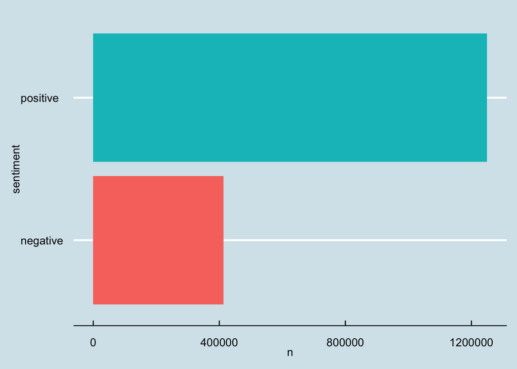

```r
sentiment_count_light %>%
  ggplot(aes(x = sentiment, y = n, fill = sentiment)) +
  geom_col() +
  theme_economist() +
  guides(fill=F) +
  coord_flip()
```

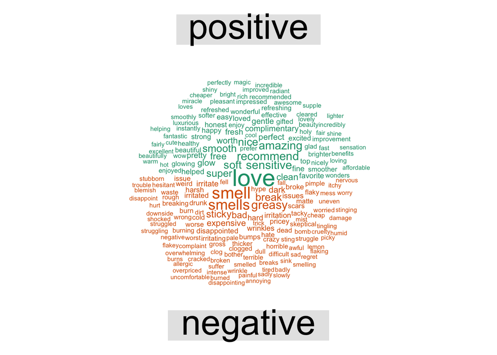

```r
# Visualize review_text Using Word Cloud
wordcloudData_light =
  review_clean_light %>%
  group_by(author_id) %>%
  unnest_tokens(output = word, input = review_text) %>%
  ungroup() %>%
  select(author_id, word) %>%
  anti_join(stop_words) %>%
  inner_join(get_sentiments('bing')) %>%
  ungroup()%>%
  count(sentiment, word, sort = T) %>%
  pivot_wider(names_from = sentiment, values_from = n, values_fill = 0) %>%
  data.frame()
rownames(wordcloudData_light) = wordcloudData_light[,'word']
wordcloudData_light = wordcloudData_light[,c('positive','negative')]
set.seed(617)
comparison.cloud(term.matrix = wordcloudData_light,scale = c(2,0.5),max.words = 200, rot.per=0)
```

#### Measure Which Attribute Category Is Most Frequently Mentioned

```r
# Extract the words and frequencies from wordcloudData_light
words = rownames(wordcloudData_light)
positive_freq = wordcloudData_light$positive
negative_freq = wordcloudData_light$negative

# Combine the data into a data frame
word_freq_light = data.frame(word = words, positive = positive_freq, negative = negative_freq)

# View the top 20 rows of the positive reviews
pos_word = word_freq_light %>%
  select(word, positive) %>%
  arrange(desc(positive)) %>%
  slice(1:20)
pos_word
```

| word | positive |
| --- | --- |
| love | 106954 |
| sensitive | 35717 |
| recommend | 35341 |
| amazing | 34211 |
| soft | 31695 |
| nice | 31051 |
| smooth | 27452 |
| super | 26417 |
| free | 20999 |
| clean | 19919 |

[output cut: 10 more lines]

```r
# View the top 20 rows of the negative reviews
neg_word = word_freq_light %>%
  select(word, negative) %>%
  arrange(desc(negative)) %>%
  slice(1:20)
neg_word
```

| word | negative |
| --- | --- |
| smell | 29292 |
| smells | 24126 |
| greasy | 17000 |
| break | 13018 |
| sticky | 11593 |
| bad | 9399 |
| expensive | 7670 |
| dark | 7494 |
| irritate | 5727 |
| hard | 5401 |

[output cut: 10 more lines]

Again, we grouped top 20 frequently appeared words in reviews into 5 categories (price, quality, package_design, ingredient, and others)

```r
# Create a mapping of words to categories
word_category_mapping = data.frame(
  word = c("smell", "smells", "greasy", "break", "sticky",
           "bad", "expensive", "dark", "irritate", "hard",
           "wrinkles", "irritation", "issues", "harsh", "disappointed",
           "pricey", "broke", "irritated", "drunk", "bumps",
           "love", "sensitive", "recommend", "amazing", "soft",
           "nice", "smooth", "super", "free", "clean",
           "worth", "glow", "perfect", "complimentary", "gentle",
           "fresh", "pretty", "fine", "helped", "favorite"),
  category = c("quality", "quality", "quality", "others", "quality",
               "others", "price", "others", "others", "others",
               "quality", "others", "others", "others", "others",
               "price", "others", "others", "others", "quality",
               "others", "quality", "others", "others", "quality",
               "others", "quality", "others", "price", "quality",
               "price", "quality", "others", "price", "quality",
               "quality", "package_design", "others", "quality", "others")
  )

# Merge the data frames to add the 'category' column to the original data (for positive reviews)
pos_word_light = pos_word %>%
  left_join(word_category_mapping, by = "word") %>%
  group_by(category) %>%
  summarize(pos_review_count = sum(positive)) %>%
  arrange(desc(pos_review_count))

pos_word_light
```

| category | pos_review_count |
| --- | --- |
| others | 269659 |
| quality | 168261 |
| price | 51977 |
| package_design | 12520 |

```r
# Merge the data frames to add the 'category' column to the original data (for negative reviews)
neg_word_light = neg_word %>%
  left_join(word_category_mapping, by = "word") %>%
    group_by(category) %>%
    summarize(neg_review_count = sum(negative)) %>%
    arrange(desc(neg_review_count))

neg_word_light
```

| category | neg_review_count |
| --- | --- |
| quality | 90053 |
| others | 69314 |
| price | 11573 |

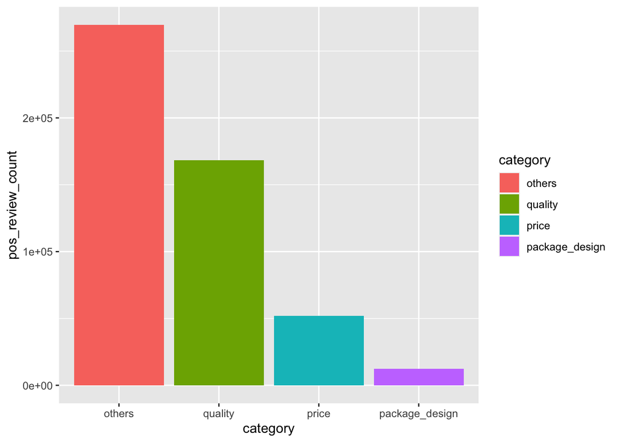

```r
# Visualize the Attribute Distribution (for positive reviews)
pos_word_light$category = factor(pos_word_light$category,
                                levels = pos_word_light$category[order(-pos_word_light$pos_review_count)])

ggplot(pos_word_light, aes(x = category, y = pos_review_count, fill = category)) +
  geom_bar(stat = "identity")
```

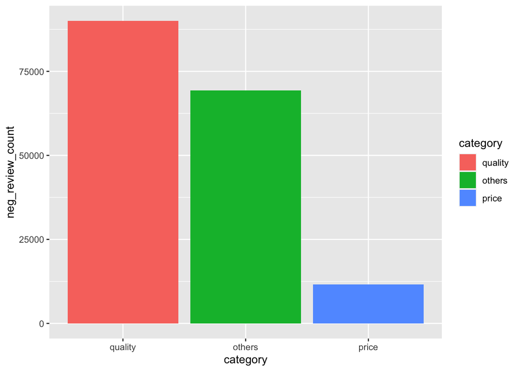

```r
# Visualize the Attribute Distribution (for negative reviews)
neg_word_light$category = factor(neg_word_light$category,
                                levels = neg_word_light$category[order(-neg_word_light$neg_review_count)])

ggplot(neg_word_light, aes(x = category, y = neg_review_count, fill = category)) +
  geom_bar(stat = "identity")
```

#### Conduct Sentiment Analysis on review_text from Medium Skin-Tone Customers

```r
# Filter Out Reviews from Medium Skin-Tone Customers
review_clean_medium = review_clean %>%
  filter(skin_tone_cat == 'medium')

head(review_clean_medium)
```

|  | author_id | review_text | skin_tone_cat |
| --- | --- | --- | --- |
| 1 | 42802569154 | The scent isn’t my favourite but it works great! I put it on every night before I go to sleep and every morning I wake up with smooth, moisturizer and soft. Packaging is amazing as well | medium |
| 2 | 45004161653 | I just got this a few days ago, it’s amazing! I love the berry scent ! It’s very hydrating and my lips are so smooth and glossy . My lips are always chapped and dry this has really helped! | medium |
| 3 | 33602438124 | i love how hydrating this makes my lips feel! perfect for an overnight lip mask or just a gloss as well! lasts forever | medium |
| 4 | 33049388574 | It’s super glossy and looks amazing but doesn’t last very long after use. | medium |
| 5 | 47136208213 | I just started using it but from the first night my lips felt way better. The next morning they even looked fuller which I’m not sure if that’s the intention but still! And the berry smell is so good! | medium |
| 6 | 5392684203 | Not worth the hype. My lips are still dry after using this product nightly, had much better results with the Ilia Lip Wrap, and it’s a cleaner product. | medium |

```r
nrow(review_clean_medium)
```

```
## [1] 178718
```

```r
# Categorize Words in review_text Using Bing
sentiment_count_medium = review_clean_medium %>%
  group_by(author_id) %>%
  unnest_tokens(output = word, input = review_text) %>%
  inner_join(get_sentiments('bing')) %>%
  group_by(sentiment) %>%
  count()
sentiment_count_medium
```

| sentiment | n |
| --- | --- |
| negative | 234824 |
| positive | 753426 |

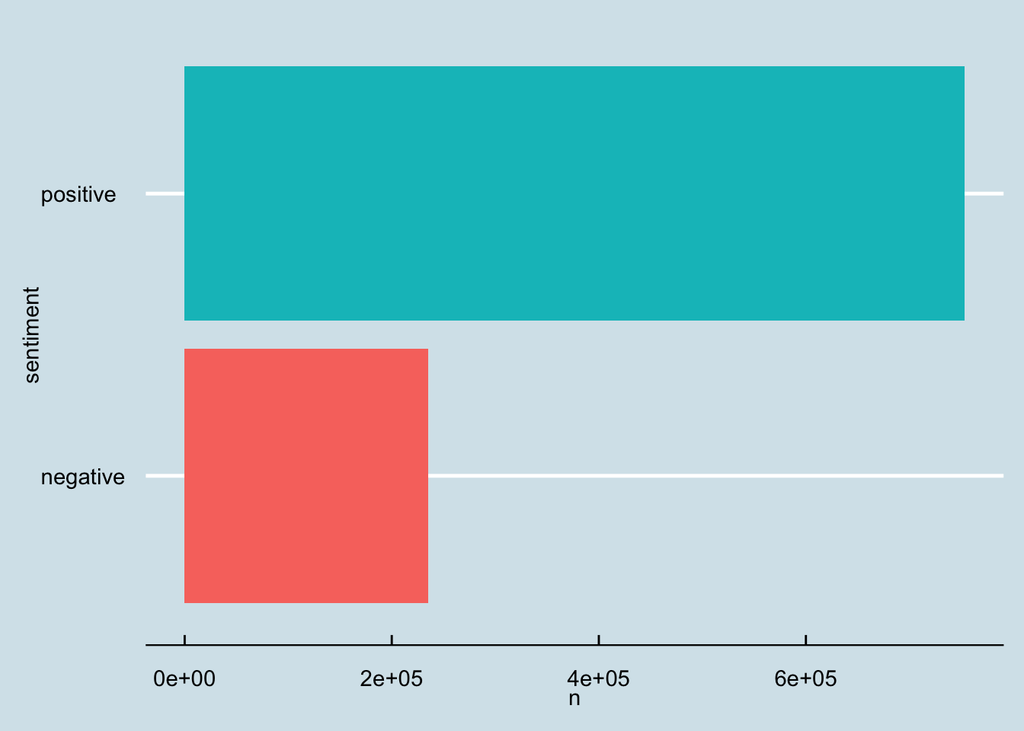

```r
sentiment_count_medium %>%
  ggplot(aes(x = sentiment, y = n, fill = sentiment)) +
  geom_col() +
  theme_economist() +
  guides(fill=F) +
  coord_flip()
```

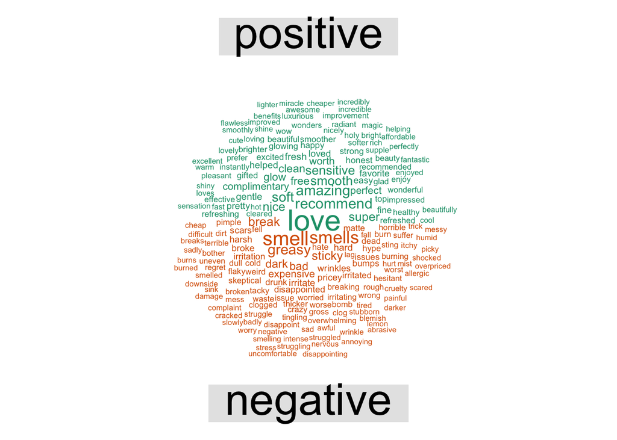

```r
# Visualize review_text Using Word Cloud
wordcloudData_medium =
  review_clean_medium %>%
  group_by(author_id) %>%
  unnest_tokens(output = word, input = review_text) %>%
  ungroup() %>%
  select(author_id, word) %>%
  anti_join(stop_words) %>%
  inner_join(get_sentiments('bing')) %>%
  ungroup()%>%
  count(sentiment, word, sort = T) %>%
  pivot_wider(names_from = sentiment, values_from = n, values_fill = 0) %>%
  data.frame()
rownames(wordcloudData_medium) = wordcloudData_medium[,'word']
wordcloudData_medium = wordcloudData_medium[,c('positive','negative')]
set.seed(617)
comparison.cloud(term.matrix = wordcloudData_medium,scale = c(2,0.5),max.words = 200, rot.per=0)
```

#### Measure Which Attribute Category Is Most Frequently Mentioned

```r
# Extract the words and frequencies from wordcloudData_medium
words = rownames(wordcloudData_medium)
positive_freq = wordcloudData_medium$positive
negative_freq = wordcloudData_medium$negative

# Combine the data into a data frame
word_freq_df = data.frame(word = words, positive = positive_freq, negative = negative_freq)

# View the top 20 rows of the positive reviews
pos_word_freq_df = word_freq_df %>%
  select(word, positive) %>%
  arrange(desc(positive)) %>%
  slice(1:20)
pos_word_freq_df
```

| word | positive |
| --- | --- |
| love | 70782 |
| recommend | 23666 |
| amazing | 22613 |
| soft | 20387 |
| smooth | 18122 |
| sensitive | 17467 |
| nice | 16344 |
| super | 16205 |
| clean | 12483 |
| free | 12070 |

[output cut: 10 more lines]

```r
# View the top 20 rows of the negative reviews
neg_word_freq_df = word_freq_df %>%
  select(word, negative) %>%
  arrange(desc(negative)) %>%
  slice(1:20)
neg_word_freq_df
```

| word | negative |
| --- | --- |
| smell | 17234 |
| smells | 13968 |
| greasy | 9677 |
| break | 7408 |
| sticky | 7059 |
| dark | 5845 |
| bad | 5559 |
| expensive | 4155 |
| hard | 2982 |
| irritate | 2957 |

[output cut: 10 more lines]

```r
# Create a mapping of words to categories
word_category_mapping = data.frame(
  word = c("smell", "smells", "dark", "greasy", "break",
           "sticky", "bad", "expensive", "harsh", "scars",
           "hard", "broke", "irritate", "matte", "bumps",
           "irritation", "pricey", "disappointed", "issues", "skeptical", "wrinkles", "irritated",
           "love", "recommend", "soft", "amazing", "smooth",
           "sensitive", "nice", "super", "glow", "clean",
           "free", "complimentary", "worth", "gentle", "perfect",
           "fresh", "loved", "pretty", "helped", "favorite", "easy"),
  category = c("quality", "quality", "others", "quality", "others",
               "quality", "others", "price", "others", "quality",
               "others", "others", "others", "quality", "quality",
               "others", "price", "others", "others", "others", "quality", "others",
               "others", "others", "quality", "others", "quality",
               "quality", "others", "others", "quality", "quality",
               "price", "price", "price", "quality", "others",
               "quality", "others", "package_design", "quality", "others", "others")
  )

# Merge the data frames to add the 'category' column to the original data (for positive reviews)
pos_word_medium = pos_word_freq_df %>%
  left_join(word_category_mapping, by = "word") %>%
  group_by(category) %>%
  summarize(pos_review_count = sum(positive)) %>%
  arrange(desc(pos_review_count))

pos_word_medium
```

| category | pos_review_count |
| --- | --- |
| others | 171611 |
| quality | 102934 |
| price | 31585 |
| package_design | 6605 |

```r
# Merge the data frames to add the 'category' column to the original data (for negative reviews)
neg_word_medium = neg_word_freq_df %>%
  left_join(word_category_mapping, by = "word") %>%
    group_by(category) %>%
    summarize(neg_review_count = sum(negative)) %>%
    arrange(desc(neg_review_count))

neg_word_medium
```

| category | neg_review_count |
| --- | --- |
| quality | 55357 |
| others | 38196 |
| price | 6753 |

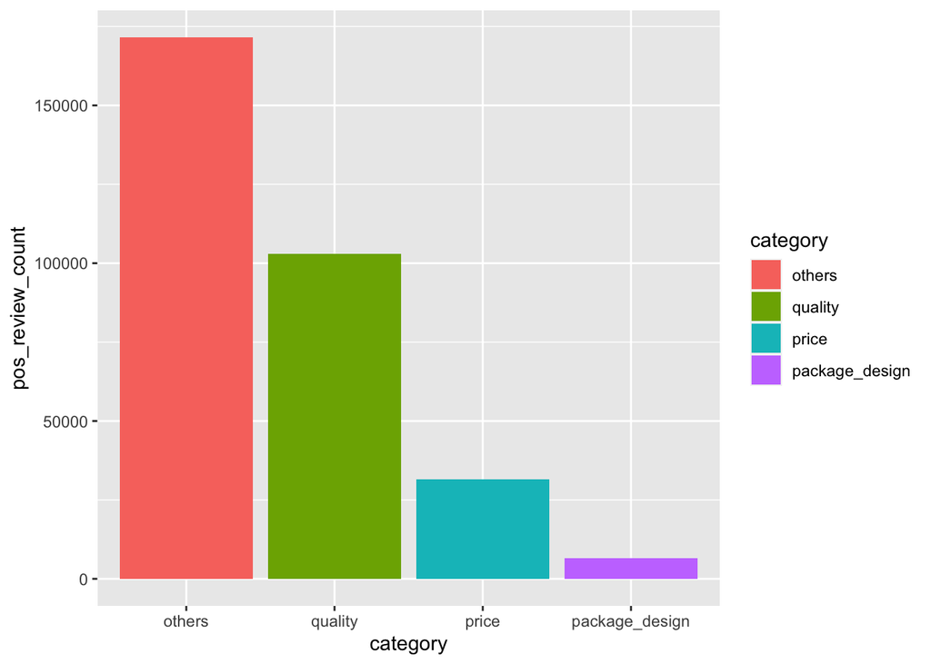

```r
# Visualize the Attribute Distribution (for positive reviews)
pos_word_medium$category = factor(pos_word_medium$category,
                                levels = pos_word_medium$category[order(-pos_word_medium$pos_review_count)])

ggplot(pos_word_medium, aes(x = category, y = pos_review_count, fill = category)) +
  geom_bar(stat = "identity")
```

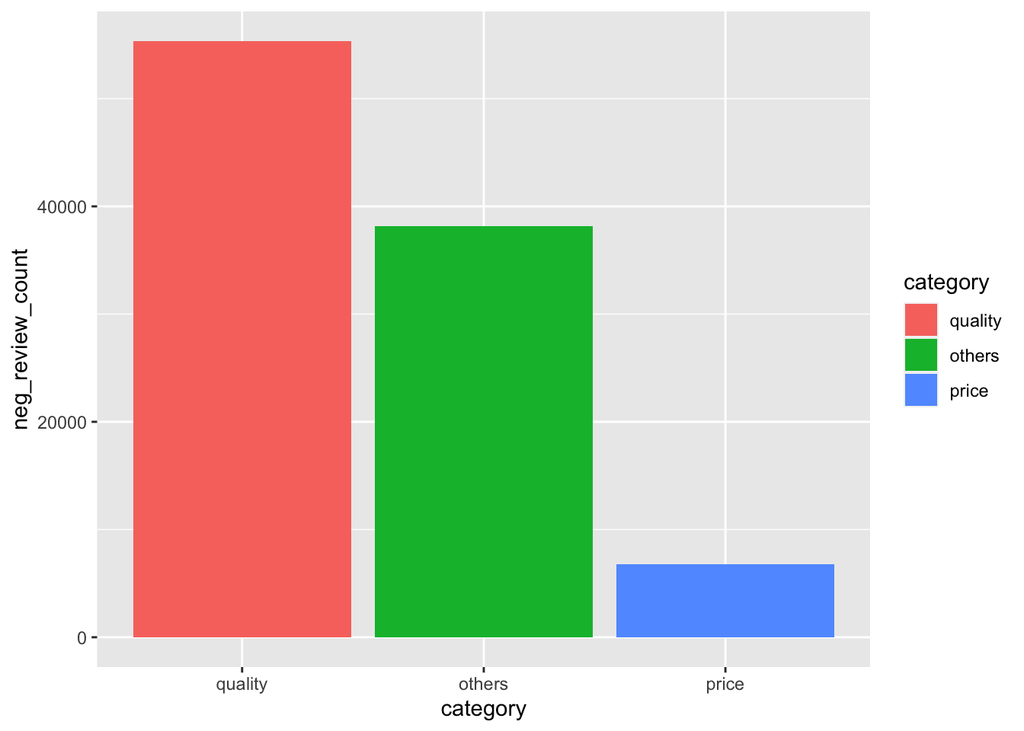

```r
# Visualize the Attribute Distribution (for negative reviews)
neg_word_medium$category = factor(neg_word_medium$category,
                                levels = neg_word_medium$category[order(-neg_word_medium$neg_review_count)])

ggplot(neg_word_medium, aes(x = category, y = neg_review_count, fill = category)) +
  geom_bar(stat = "identity")
```

#### Conduct Sentiment Analysis on review_text from Tan Skin-Tone Customers

```r
# Filter Out Reviews from Tan Skin-Tone Customers
review_clean_tan = review_clean %>%
  filter(skin_tone_cat == 'tan')

head(review_clean_tan)
```

|  | author_id | review_text | skin_tone_cat |
| --- | --- | --- | --- |
| 1 | 6835882311 | I wanted to love this product so bad because of all the amazing reviews but it honestly makes my lips so disgustingly chapped. I’ve used other lip masks that this hasn’t happened with and went back to… | tan |
| 2 | 2626890840 | Literally love all of Laneige products. The lip sleeping mask has an amazing slip and it’s just the perfect overnight mask. Not sticky at all. | tan |
| 3 | 10378079599 | Amazing!!! My lips literally react so badly to every single lip balm or chapstick. I had a allergic reaction to jack black spf lip balm and this saved my lips!! They are super soft and moisturized (: | tan |
| 4 | 46115455920 | This has really helped my dry lips especially in the winter. A must have in my routine! | tan |
| 5 | 32394665163 | Love!! So moisturizing and cute. Love putting it on before I go out or before bed and it leaves my lips feeling soft for hours!! | tan |
| 6 | 5353168486 | After using the entire product I am not impressed with how much the product dissipates once applied to the surface of your lips. I like it for the thick shine and smell but that’s about it. Would not … | tan |

```r
nrow(review_clean_tan)
```

```
## [1] 31706
```

```r
# Categorize Words in review_text Using Bing
sentiment_count_tan = review_clean_tan %>%
  group_by(author_id) %>%
  unnest_tokens(output = word, input = review_text) %>%
  inner_join(get_sentiments('bing')) %>%
  group_by(sentiment) %>%
  count()
sentiment_count_tan
```

| sentiment | n |
| --- | --- |
| negative | 39557 |
| positive | 125637 |

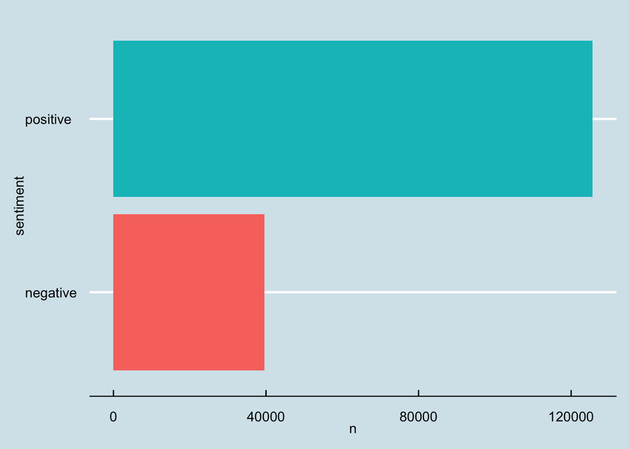

```r
sentiment_count_tan %>%
  ggplot(aes(x = sentiment, y = n, fill = sentiment)) +
  geom_col() +
  theme_economist() +
  guides(fill=F) +
  coord_flip()
```

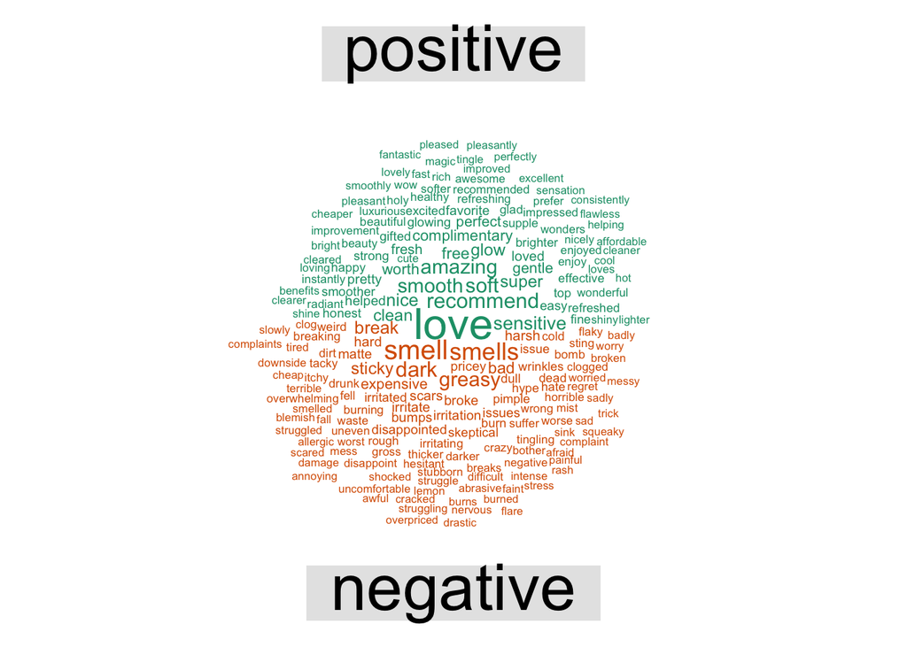

```r
# Visualize review_text Using Word Cloud
wordcloudData_tan =
  review_clean_tan %>%
  group_by(author_id) %>%
  unnest_tokens(output = word, input = review_text) %>%
  ungroup() %>%
  select(author_id, word) %>%
  anti_join(stop_words) %>%
  inner_join(get_sentiments('bing')) %>%
  ungroup()%>%
  count(sentiment, word, sort = T) %>%
  pivot_wider(names_from = sentiment, values_from = n, values_fill = 0) %>%
  data.frame()
rownames(wordcloudData_tan) = wordcloudData_tan[,'word']
wordcloudData_tan = wordcloudData_tan[,c('positive','negative')]
set.seed(617)
comparison.cloud(term.matrix = wordcloudData_tan,scale = c(2,0.5),max.words = 200, rot.per=0)
```

#### Measure Which Attribute Category Is Most Frequently Mentioned

```r
# Extract the words and frequencies from wordcloudData_tan
words = rownames(wordcloudData_tan)
positive_freq = wordcloudData_tan$positive
negative_freq = wordcloudData_tan$negative

# Combine the data into a data frame
word_freq_df = data.frame(word = words, positive = positive_freq, negative = negative_freq)

# View the top 20 rows of the positive reviews
pos_word_freq_df = word_freq_df %>%
  select(word, positive) %>%
  arrange(desc(positive)) %>%
  slice(1:20)
pos_word_freq_df
```

| word | positive |
| --- | --- |
| love | 11853 |
| recommend | 3881 |
| soft | 3661 |
| amazing | 3497 |
| smooth | 3394 |
| sensitive | 2926 |
| nice | 2531 |
| super | 2299 |
| glow | 2242 |
| clean | 2116 |

[output cut: 10 more lines]

```r
# View the top 20 rows of the negative reviews
neg_word_freq_df = word_freq_df %>%
  select(word, negative) %>%
  arrange(desc(negative)) %>%
  slice(1:20)
neg_word_freq_df
```

| word | negative |
| --- | --- |
| smell | 2664 |
| smells | 2179 |
| dark | 1712 |
| greasy | 1544 |
| break | 1099 |
| sticky | 997 |
| bad | 871 |
| expensive | 650 |
| harsh | 550 |
| scars | 500 |

[output cut: 10 more lines]

```r
# Create a mapping of words to categories
word_category_mapping = data.frame(
  word = c("smell", "smells", "dark", "greasy", "break",
           "sticky", "bad", "expensive", "harsh", "scars",
           "hard", "broke", "irritate", "matte", "bumps",
           "irritation", "pricey", "disappointed", "issues", "skeptical",
           "love", "recommend", "soft", "amazing", "smooth",
           "sensitive", "nice", "super", "glow", "clean",
           "free", "complimentary", "worth", "gentle", "perfect",
           "fresh", "loved", "pretty", "helped", "favorite"),
  category = c("quality", "quality", "others", "quality", "others",
               "quality", "others", "price", "others", "quality",
               "others", "others", "others", "quality", "quality",
               "others", "price", "others", "others", "others",
               "others", "others", "quality", "others", "quality",
               "quality", "others", "others", "quality", "quality",
               "price", "price", "price", "quality", "others",
               "quality", "others", "package_design", "quality", "others")
  )

# Merge the data frames to add the 'category' column to the original data (for positive reviews)
pos_word_tan = pos_word_freq_df %>%
  left_join(word_category_mapping, by = "word") %>%
  group_by(category) %>%
  summarize(pos_review_count = sum(positive)) %>%
  arrange(desc(pos_review_count))

pos_word_tan
```

| category | pos_review_count |
| --- | --- |
| others | 27600 |
| quality | 18140 |
| price | 5323 |
| package_design | 1086 |

```r
# Merge the data frames to add the 'category' column to the original data (for negative reviews)
neg_word_tan = neg_word_freq_df %>%
  left_join(word_category_mapping, by = "word") %>%
    group_by(category) %>%
    summarize(neg_review_count = sum(negative)) %>%
    arrange(desc(neg_review_count))

neg_word_tan
```

| category | neg_review_count |
| --- | --- |
| quality | 8783 |
| others | 7267 |
| price | 1062 |

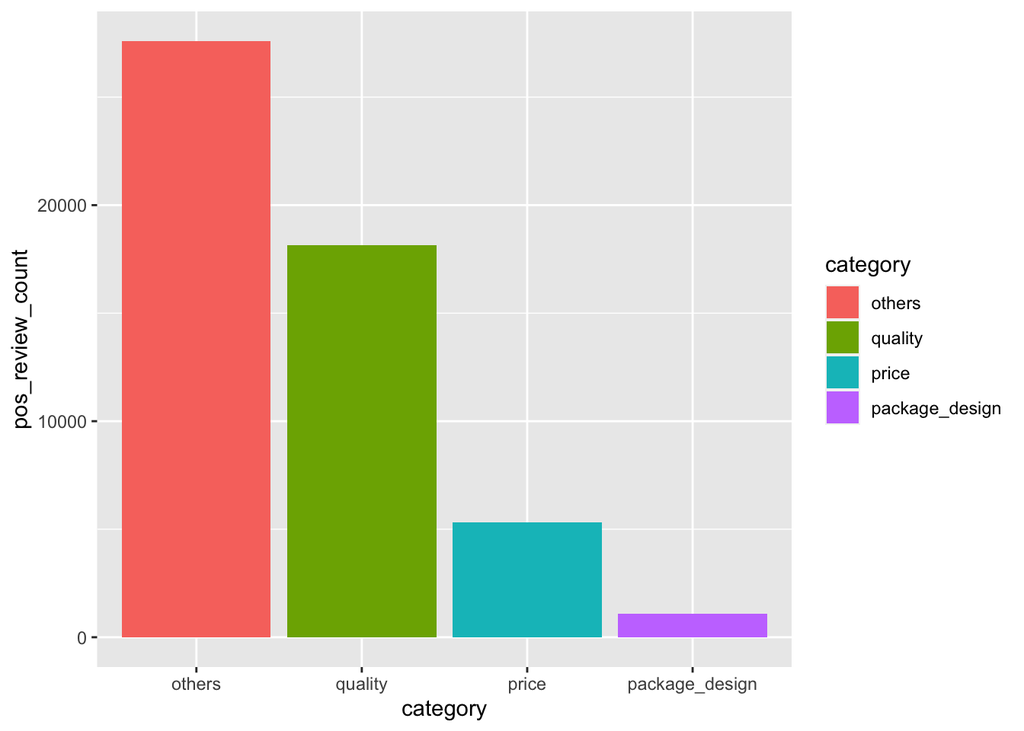

```r
# Visualize the Attribute Distribution (for positive reviews)
pos_word_tan$category = factor(pos_word_tan$category,
                                levels = pos_word_tan$category[order(-pos_word_tan$pos_review_count)])

ggplot(pos_word_tan, aes(x = category, y = pos_review_count, fill = category)) +
  geom_bar(stat = "identity")
```

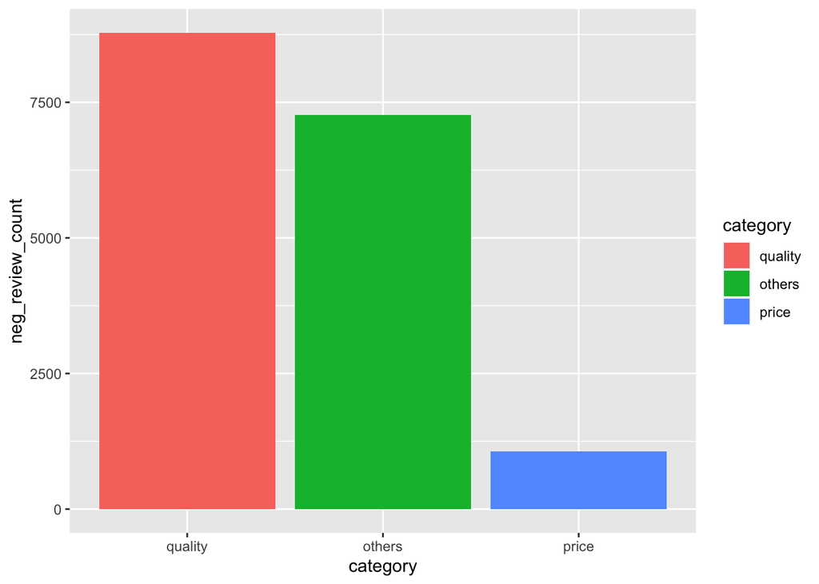

```r
# Visualize the Attribute Distribution (for negative reviews)
neg_word_tan$category = factor(neg_word_tan$category,
                                levels = neg_word_tan$category[order(-neg_word_tan$neg_review_count)])

ggplot(neg_word_tan, aes(x = category, y = neg_review_count, fill = category)) +
  geom_bar(stat = "identity")
```

#### Result

We are using chi-square test for independence to measure whether there is a significant difference in word category distribution between customers with different skin tones.

Since the p-value we got from chi-square test is > 0.05, we fail to reject the null hypothesis, indicating that there is no evidence to suggest that the word category proportions are significantly different across skin-tone groups.

```r
# combine positive and negative word count tables into one dataframe for each skin-tone group (light, medium, tan)
# light skin tone
light_word_pos_neg =
  full_join(pos_word_light, neg_word_light, by = "category", suffixes = c("_pos", "_neg"))

light_word_cat = data.frame(
  category = light_word_pos_neg$category,
  count = ifelse(is.na(light_word_pos_neg$pos_review_count), light_word_pos_neg$neg_review_count,
                 ifelse(is.na(light_word_pos_neg$neg_review_count), light_word_pos_neg$pos_review_count,
                        light_word_pos_neg$pos_review_count + light_word_pos_neg$neg_review_count))
)
light_word_cat
```

| category | count |
| --- | --- |
| others | 338973 |
| quality | 258314 |
| price | 63550 |
| package_design | 12520 |

```r
# medium skin tone
medium_word_pos_neg =
  full_join(pos_word_medium, neg_word_medium, by = "category", suffixes = c("_pos", "_neg"))

medium_word_cat = data.frame(
  category = medium_word_pos_neg$category,
  count = ifelse(is.na(medium_word_pos_neg$pos_review_count), medium_word_pos_neg$neg_review_count,
                 ifelse(is.na(medium_word_pos_neg$neg_review_count), medium_word_pos_neg$pos_review_count,
                        medium_word_pos_neg$pos_review_count + medium_word_pos_neg$neg_review_count))
)
medium_word_cat
```

| category | count |
| --- | --- |
| others | 209807 |
| quality | 158291 |
| price | 38338 |
| package_design | 6605 |

```r
# tan skin tone
tan_word_pos_neg =
  full_join(pos_word_tan, neg_word_tan, by = "category", suffixes = c("_pos", "_neg"))

tan_word_cat = data.frame(
  category = tan_word_pos_neg$category,
  count = ifelse(is.na(tan_word_pos_neg$pos_review_count), tan_word_pos_neg$neg_review_count,
                 ifelse(is.na(tan_word_pos_neg$neg_review_count), tan_word_pos_neg$pos_review_count,
                        tan_word_pos_neg$pos_review_count + tan_word_pos_neg$neg_review_count))
)
tan_word_cat
```

| category | count |
| --- | --- |
| others | 34867 |
| quality | 26923 |
| price | 6385 |
| package_design | 1086 |

```r
# Perform chi-square test for independence for light, medium, and tan skin tone groups
combined_matrix = rbind(light_word_cat$count, medium_word_cat$count, tan_word_cat$count)
prop_table = prop.table(combined_matrix, margin = 1); prop_table
```

```
##           [,1]      [,2]       [,3]       [,4]
## [1,] 0.5034076 0.3836212 0.09437787 0.01859341
## [2,] 0.5079568 0.3832331 0.09281887 0.01599115
## [3,] 0.5034146 0.3887180 0.09218752 0.01567982
```

```r
library(stats)
chisq.test(prop_table)
```

```
##
##  Pearson's Chi-squared test
##
## data:  prop_table
## X-squared = 0.00040876, df = 6, p-value = 1
```

```r
# Add column names for the prop_table (to show on the text report)
rownames(prop_table) = c("Light", "Medium", "Tan")
colnames(prop_table) = c("others", "quality", "price", "package_design")
prop_table
```

```
##           others   quality      price package_design
## Light  0.5034076 0.3836212 0.09437787     0.01859341
## Medium 0.5079568 0.3832331 0.09281887     0.01599115
## Tan    0.5034146 0.3887180 0.09218752     0.01567982
```